# The turn bar

Time and turns are an important element for the player to choose a strategy in an “active time battle” system.

There are different ways to represent the turns’ order and how quickly a battler can be ready to act. The gauges in old Final Fantasy games only give you information about playable characters, not enemies.

[figure not shown]

I’ve chosen an approach that shows all battlers instead, each represented by an icon that moves along an axis.

[figure not shown]

Some titles like Grandia on PlayStation 1 used this kind of UI widget, sometimes with an extra area to represent a skill’s cast duration.

[figure not shown]

Our turn bar will rely on two elements:

1. An icon representing a battler. Its frame shows if it’s an ally or an enemy.
2. A bar that instantiates, displays, and updates the position of icons.

I will also show you how to keep this user interface separate from the game world and how to give it the information it needs to function.

## Designing the battler icon

Let’s start with the icons as we’ll instantiate them later in the turn bar.

You’re going to use two sprites to make them: a frame and an icon representing the battler.

Create a new scene with two TextureRect nodes named *UIBattlerIcon* and *Icon* respectively. The *UIBattlerIcon* is our background frame, and the *Icon* will display the battler’s image.

[figure not shown]

In the course project, you will find the sprites `portrait_bg_*.png` for the *UIBattlerIcon* and `bear.png` and `bugcat.png` for the *Icon* node. Assign them to the corresponding *TextureRect* node.

[figure not shown]

At this stage, your scene should look like this.

[figure not shown]

We need to change the nodes’ properties to fit the icon inside the background.

Select the *Icon* node and in the *Inspector* turn on the Expand option. Doing so allows us to resize the node freely; the texture will shrink or expand to fit the node’s bounding box according to the *Stretch Mode*. Change the *Stretch Mode* to *Keep Aspect Centered*, so the node always retains the image’s aspect ratio. You can also check *Flip H* to mirror the image horizontally.

[figure not shown]

Then, to fit the texture into the background, use the *Layout -> Full Rect* command in the toolbar.

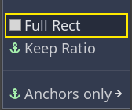

The icon is still too big. You can add margins relative to the parent *UIBattlerIcon* node by resizing the *Icon* in the viewport. With the *Select Mode* active in the toolbar (`Q`), click and drag the Icon’s corner handles while pressing `Shift` `Alt` on your keyboard. Those keys allow you to scale uniformly around the node’s center.

[figure not shown]

### The UIBattlerIcon’s script

Attach a script to the *UIBattlerIcon* node.

[output not shown]

## Designing the turn bar

Next up is the turn bar, which will instantiate the icons we just created for each battler on the field.

Create a new scene with a *Control* at the root named *UITurnBar*, a *TextureRect* named *Background*, and an *AnimationPlayer*.

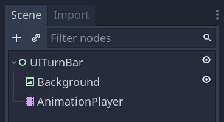

Select the *Background* node and assign it to the turn bar’s background image, `turn_bar_bg.png`. The sprite should appear in the top-left corner of the viewport.

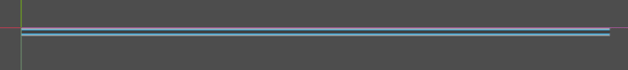

The background image may be too wide by default. We can change some properties to resize it horizontally. In the *Inspector*, set it to *Expand* and change the *Stretch Mode* to *Keep Aspect Covered*. You can now resize the *Background* node horizontally to crop the bar.

Let’s anchor the turn bar to the top edge of the viewport. Select the *UITurnBar* node and apply the *Layout -> Center Top* command to anchor it to the top edge’s middle point.

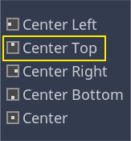

Then, apply *Layout -> Center* to the *Background* node. It centers inside the parent control node. Finally, resize the *UITurnBar* vertically to move the turn bar closer to the top edge.

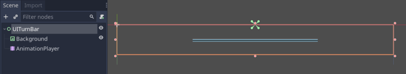

### The fade animations

We’re going to use animations to fade various UI widgets in and out. Select the *AnimationPlayer* and create the following three animations.

As animations directly change node properties’ values in Godot, even in the editor, I like to have a “setup” animation to reset everything. This is an animation with only one frame that resets properties other animations modify. Here, we only need one key in the *UITurnBar*’s *Modulate* property.

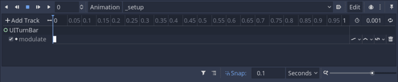

The fade-in animation uses two keys to take the node from fully transparent to fully opaque. Notice that the animation is set to *Autoplay On Load* (icon highlighted in yellow below).

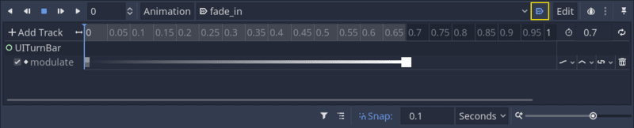

To animate the node’s opacity, you want to modify the alpha channel of the *Modulate* property in the *Inspector*.

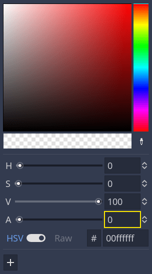

The fade-out animation is a copy of the fade-in but with the two keys swapped.

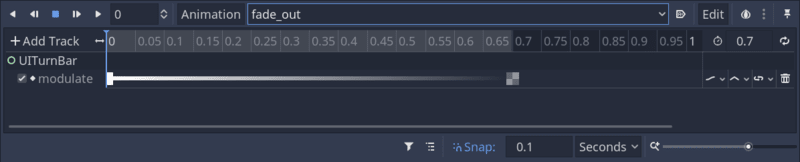

## Coding the turn bar

We now have everything our turn bar needs to work, so let’s move to code. Attach a new script to the *UITurnBar* node.

```
# Timeline representing the turn order of all battlers in the arena.
# Battler icons move along the timeline as their readiness updates.
extends Control

# You can preload scenes with relative paths when they're in the same directory. The line below will
# work as long as `UIBattlerIcon.tscn` is in the same directory as `UITurnBar.gd`.
# When there's only one scene meant to be instanced by another, I like to preload it like that
# instead of using an `export var`.
const BattlerIcon := preload("UIBattlerIcon.tscn")

onready var _background: TextureRect = $Background
onready var _anim_player: AnimationPlayer = $AnimationPlayer


# To initialize the turn bar, we pass all the battlers we want to display.
func setup(battlers: Array) -> void:
    for battler in battlers:
        # We first calculate the right icon background using the `Types` enum from `UIBattlerIcon`.
        # Below, I'm using the ternary operator. It picks the first value if the condition is `true`,
        # otherwise, it picks the second value.
        var type: int = (
            UIBattlerIcon.Types.PLAYER
            if battler.is_party_member
            else UIBattlerIcon.Types.ENEMY
        )
        # We create an instance of the `UIBattlerIcon` scene using a function and add it as a child.
        var icon: UIBattlerIcon = create_icon(type, battler.ui_data.texture)
        # We get to use the `Battler.readiness_changed` signal again to move the icons along the turn bar.
        # Once again, we bind the icon to the callback for each battler, so we don't have to worry
        # about which battler corresponds to which icon later.
        battler.connect("readiness_changed", self, "_on_Battler_readiness_changed", [icon])
        _background.add_child(icon)


# Creates a new instance of `UIBattlerIcon`, initializes it, adds it as a child of `background`, and
# returns it.
func create_icon(type: int, texture: Texture) -> UIBattlerIcon:
    var icon: UIBattlerIcon = BattlerIcon.instance()
    icon.icon = texture
    icon.type = type
    # We calculate where to position the icon, ranging between the left and right limits of the
    # `background` texture. Note this range is only in the X axis: the vector's X and Y components are
    # the minimum and the maximum icon's X position.
    icon.position_range = Vector2(
        # TextureRect nodes have their pivot and origin in the top-left corner, so we need to offset
        # the scale by half the icon's size.
        -icon.rect_size.x / 2.0,
        -icon.rect_size.x / 2.0 + _background.rect_size.x
    )
    return icon


# The following two functions encapsulate animation playback and the animation player.
func fade_in() -> void:
    _anim_player.play("fade_in")


func fade_out() -> void:
    _anim_player.play("fade_out")


# This is where we update the position of each icon. Every time a battler emits the
# "readiness_changed" signal, we use this value to snap the corresponding icon to a new location.
func _on_Battler_readiness_changed(readiness: float, icon: UIBattlerIcon) -> void:
    # We call the `UIBattlerIcon.snap()` function we defined previously. I recommend using a
    # function or dedicated property here because polishing the game, you might want to animate the
    # icon's movement.
    icon.snap(readiness / 100.0)
```

## Instantiating the bar in the battle

To initialize the turn bar, we need an instance of it in our *CombatDemo* scene. We also need to pass it the list of battlers in the encounter by calling `UITurnBar.setup()`.

To keep UI widgets above the battlefield at all times, I recommend to add a *CanvasLayer* node. In the image below, I’ve named it *UI* and added an instance of `UITurnBar.tscn` as a child of it.

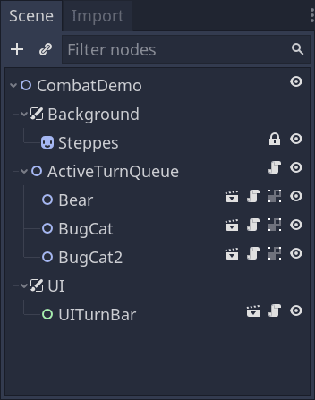

We’re going to use the *UI* and the *ActiveTurnQueue*’s common parent, the *CombatDemo* node, to pass data to the *UITurnBar*. Attach a new script to *CombatDemo*.

```
extends Node2D

# We're going to get the battlers from the `ActiveTurnQueue` node.
onready var active_turn_queue := $ActiveTurnQueue
onready var ui_turn_bar := $UI/UITurnBar


# We set up the turn bar when the node is ready, which ensures all its children also are ready.
func _ready() -> void:
    var battlers: Array = active_turn_queue.battlers
    ui_turn_bar.setup(active_turn_queue.battlers)
```

And this is all we need to get the turn bar working. All the rest is encapsulated in our `UITurnBar` and `UIBattlerIcon` classes.

[figure not shown]